# **Malaria Detection**

**by: Nicolás Salazar Beltrán ([nicolas-salbe.github.io](https://nicolas-salbe.github.io/))**

## **Context**

Although preventable and curable, malaria cases have steadily increased in the past decades. According to the WHO, there were an alarming estimated 247 million cases of malaria in 2021 worldwide. The vast majority of these cases are found in underdeveloped tropical countries where socioeconomic conditions make malaria prevention and treatment a significant challenge.  
Regarding treatment, early diagnosis of malaria leads to reduced disease severity, death prevention and lower transmission rates. Parasitological diagnosis of malaria relies on light microscopy or immunochromatographic RDTs (Rapid Diagnostic Testing). Particularly, light microscopy requires professional inspection of infected blood cells performed by a microscopist who may not be widely present in malaria-affected regions and may not be able to effectively handle large amount of samples.  
Supporting early detection of malaria through an automated diagnosis system would specially benefit vulnerable populations that have limited access to healthcare and would help better channeling treatment efforts and resources.  
One such system could be based on a Deep Learning classifier that can repeatability and accurately process microscopy images to determine whether the sample is infected by the malaria parasite or not.  
*Sources*:  
[WHO1](https://www.who.int/news-room/fact-sheets/detail/malaria), [WHO2](https://www.who.int/teams/global-malaria-programme/case-management/diagnosis), [WHO3](https://app.magicapp.org/#/guideline/LwRMXj/section/L0v9rE)

## **Objectives**

The objective of this project is to develop a Deep Learning model that can support malaria diagnosis by classifying red blood cells microscopy images as coming from a parasitized or an uninfected sample.

## **Key questions**

- How well can the developed model tell the difference between a parasitized and an uninfected cells?
- How many of the blood samples classified as parasitized are actually parasitized?
- How many of the blood samples classified as uninfected are actually parasitized?

## **Problem formulation**

The data science problem addressed by this project is to build a CNN model that can detect patterns in a dataset of labeled red blood images and can learn how to classify unseen images as coming from a parasitized or an unifected blood sample.

## **Data Description**

There are a total of 24,958 train and 2,600 test images (colored) that we have taken from microscopic images. These images are of the following categories:

**Parasitized:** The parasitized cells contain the Plasmodium parasite which causes malaria  
**Uninfected:** The uninfected cells are free of the Plasmodium parasites

### **Loading libraries**

```
'2.12.0'
```

### **Let us load the data**

**Note:**

- You must download the dataset from the link provided on Olympus and upload the same to your Google Drive. Then unzip the folder.

The extracted folder has different folders for train and test data will contain the different sizes of images for parasitized and uninfected cells within the respective folder name.

The size of all images must be the same and should be converted to 4D arrays so that they can be used as an input for the convolutional neural network. Also, we need to create the labels for both types of images to be able to train and test the model.

Let's do the same for the training data first and then we will use the same code for the test data as well.

```
['cell_images/train/uninfected',
 'cell_images/train/parasitized',
 'cell_images/test/uninfected',
 'cell_images/test/parasitized']
```

Before resizing let's get a picture of how different image sizes are among the dataset:

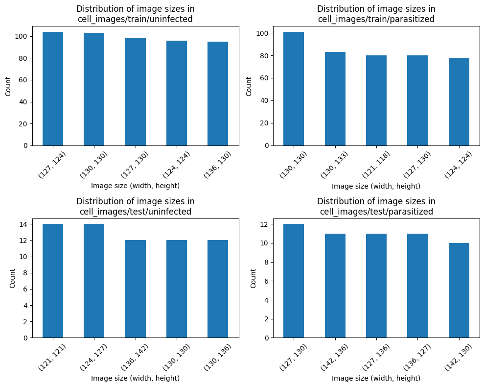

- Image size across the dataset is quite diverse although most of these sizes are larger than 120x120 pixels.
- It is not explicitly required in this notebook but the project's FAQ indicates that all images should be resized to 64x64 pixels. This new size seems to be a good trade-off for staying close to the aspect ratio of the original images.

For this binary classification problem we will use the following labels:

- *1*: parasitized
- *0*: uninfected

### **Check the shape of train and test images**

```
((24958, 64, 64, 3), (2600, 64, 64, 3))
```

### **Check the shape of train and test labels**

```
((24958,), (2600,))
```

#### **Observations and insights: **_****

- The training dataset consists of 24958 RGB images of size 64x64 pixels organized in a 4D array
- The testing dataset consists of 2600 RGB images of size 64x64 pixels organized in a 4D array

### **Check the minimum and maximum range of pixel values for train and test images**

```
(0, 255)
```

```
(0, 255)
```

#### **Observations and insights: **_****

- Pixel value range is 0-255 for both the train and the test images

### **Count the number of values in both uninfected and parasitized**

```
1.0    12582
0.0    12376
dtype: int64
```

```
1.0    0.504127
0.0    0.495873
dtype: float64
```

- The train dataset is not perfectly balanced as there is around 1% more images corresponding to the parasitized class than the uninfected class
- This unbalance could make the model perform slightly better when detecting parasitized cells in comparison to detecting uninfected cells
- Let's assume for now that the unbalance is negligible

### **Normalize the images**

```
((24958, 64, 64, 3), (2600, 64, 64, 3))
```

#### **Observations and insights: **_****

- Data normalization is just a rescaling so it doesn't affect the original shapes of the independent variable arrays.

### **Plot to check if the data is balanced**

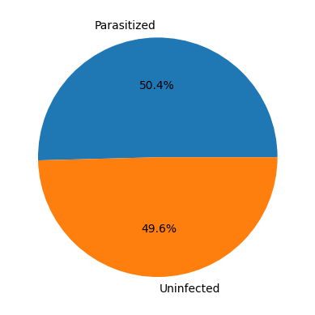

#### **Observations and insights: **_****

- The train dataset is not perfectly balanced as there is around 1% more images corresponding to the parasitized class than the uninfected class
- This unbalance could make the model perform slightly better when detecting parasitized cells in comparison to detecting uninfected cells
- Let's assume for now that the unbalance is negligible

### **Data Exploration**

Let's visualize the images from the train data

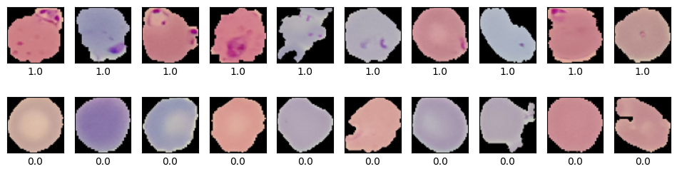

#### **Observations and insights: **_****

- Cells images show different forms and colors
- Parasitized cells show a sort of stains in random positions
- Uninfected cells show a uniform color across their area
- A model that can learn color patterns, more than shape patterns, will likely be able to perform well

### **Visualize the images with subplot(6, 6) and figsize = (12, 12)**

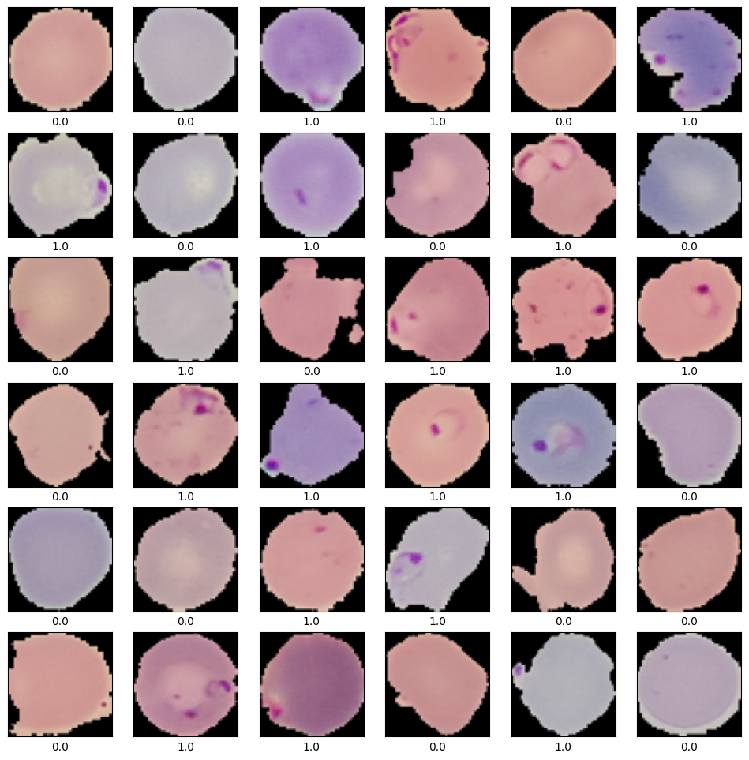

#### **Observations and insights:**

- Cells images show different forms and colors
- Parasitized cells show a sort of stains in random positions
- Uninfected cells show a uniform color across their area
- A model that can learn color patterns, more than shape patterns, will likely be able to perform well

### **Plotting the mean images for parasitized and uninfected**

The mean image of the parasitized or the uninfected training subsets is an RGB 64x64 pixels image which pixel values are calculated as the mean of all the pixel values of the corresponding pixel.

**Mean image for parasitized**

```
(64, 64, 3)
```

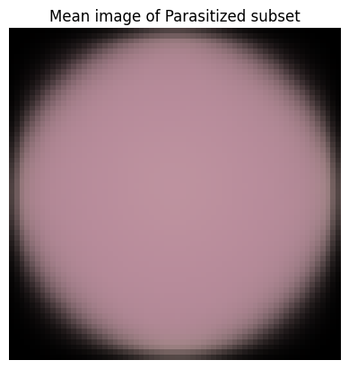

**Mean image for uninfected**

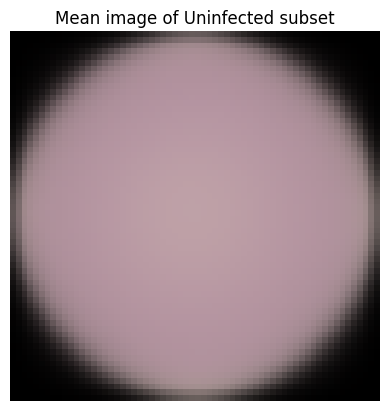

#### **Observations and insights: **_****

- The mean images smooth out the color and shape of the corresponding image subset
- Uninfected cells on average seem to be of a slightly more pale color than those of parasitized cells

### **Converting RGB to HSV of Images using OpenCV**

HSV (Hue Saturation Value) is a colorspace that is better suited than RGB to handle color characteristics of images.

RGB images from our processed arrays cannot be directly converted into HSV arrays because OpenCV expects the images to be in BRG format for correct conversion. Let's then first open the original images of the dataset in BRG and then convert them to HSV.

### **Converting the train data**

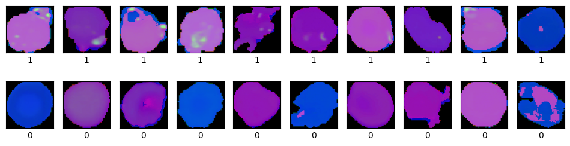

### **Converting the test data**

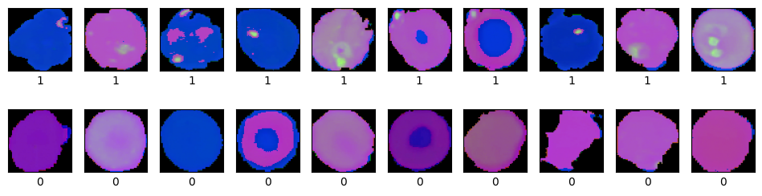

#### **Observations and insights: **_****

- HSV images help to make more evident that parasitized cells seem to feature specific color pattern strains that are not present in uninfected cells.

### **Processing Images using Gaussian Blurring**

Gaussian blurring is an image processing method that smoothes out large pixel variations such that the resulting image seems to be blur. This helps removing source image noise for some applications.

### **Gaussian Blurring on train data**

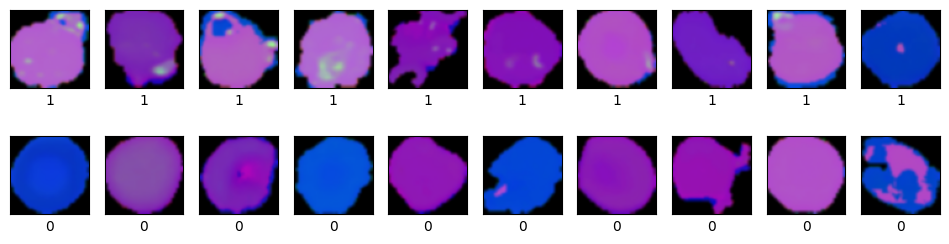

### **Gaussian Blurring on test data**

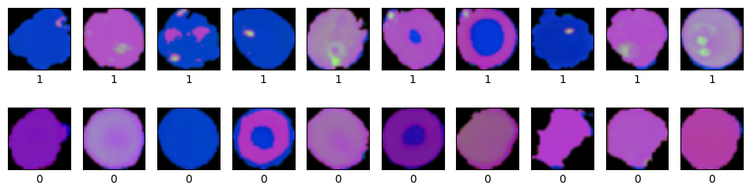

#### **Observations and insights: **_****

**Think About It:** Would blurring help us for this problem statement in any way? What else can we try?

- Gaussian blurring is not useful for this application because the target pattern to highlight is color rather than shape
- A more useful filter could be a contrast filter that can enhance the color differences in a cell

## **Model Building**

### **Base Model**

**Note:** The Base Model has been fully built and evaluated with all outputs shown to give an idea about the process of the creation and evaluation of the performance of a CNN architecture. A similar process can be followed in iterating to build better-performing CNN architectures.

### **Importing the required libraries for building and training our Model**

#### **One Hot Encoding the train and test labels**

### **Building the model**

Since we are looking for a model that can learn color patterns in the cells images a CNN is a convenient choice in terms of performance, complexity and computation power demand. Let's start with a CNN with 2 convolutional layers and no regularization.

```
Model: "sequential"
_________________________________________________________________
 Layer (type)                Output Shape              Param #
=================================================================
 conv2d (Conv2D)             (None, 64, 64, 16)        448

 conv2d_1 (Conv2D)           (None, 64, 64, 32)        4640

 max_pooling2d (MaxPooling2D  (None, 32, 32, 32)       0
 )

 flatten (Flatten)           (None, 32768)             0

 dense (Dense)               (None, 32)                1048608

 dense_1 (Dense)             (None, 2)                 66

=================================================================
Total params: 1,053,762
Trainable params: 1,053,762
Non-trainable params: 0
_________________________________________________________________
```

### **Compiling the model**

**Using Callbacks**

**Fit and train our Model**

Kera's *fit* method extracts the validation data by taking the last *validation_split* portion of the input data. Since our training arrays are ordered by class in almost equal parts, passing these arrays to *fit* would lead to validating only on the *uninfected* cell images.  
This is unconvenient as both the validation AND the training processes will be biased.

Let's then generate a new couple of shuffled training arrays.

Now we can run the fitting with the shuffled arrays.

### **Evaluating the model on test data**

```
array([1., 1., 1., ..., 0., 0., 0.])
```

```
Test accuracy of cnn_model_base:  0.9669
```

**Plotting the confusion matrix**

```
array([1, 1, 1, ..., 0, 0, 0])
```

```
Classification Report:

              precision    recall  f1-score   support

         0.0       0.96      0.98      0.97      1300
         1.0       0.98      0.96      0.97      1300

    accuracy                           0.97      2600
   macro avg       0.97      0.97      0.97      2600
weighted avg       0.97      0.97      0.97      2600
```

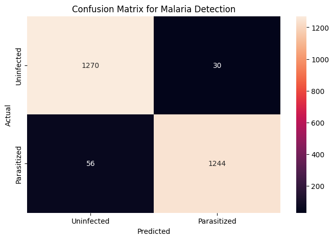

**Plotting the train and validation curves**

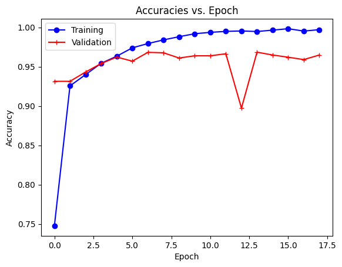

|  | cnn_model_base |
| --- | --- |
| description | 2x conv layers, 1 fc layer, relu, no regulariz... |
| # trainable parameters | 1053762 |
| epochs ran | 18 |
| training accuracy | 0.9972 |
| validation accuracy | 0.9649 |
| test accuracy | 0.9669 |
| test precision (parasitized) | 0.9765 |
| test recall (parasitized) | 0.9569 |

- Although the training accuracy is quite high, the validation accuracy stays behind significantly.
- The model is clearly overfitting the training data, so regularization is needed.

So now let's try to build another model with few more add on layers and try to check if we can try to improve the model. Therefore try to build a model by adding few layers if required and altering the activation functions.

### **Model 1**

#### **Trying to improve the performance of our model by adding new layers**

### **Building the Model**

```
Model: "sequential"
_________________________________________________________________
 Layer (type)                Output Shape              Param #
=================================================================
 conv2d (Conv2D)             (None, 64, 64, 64)        1792

 max_pooling2d (MaxPooling2D  (None, 32, 32, 64)       0
 )

 conv2d_1 (Conv2D)           (None, 32, 32, 32)        18464

 max_pooling2d_1 (MaxPooling  (None, 16, 16, 32)       0
 2D)

 conv2d_2 (Conv2D)           (None, 16, 16, 32)        9248

 max_pooling2d_2 (MaxPooling  (None, 8, 8, 32)         0
 2D)

 flatten (Flatten)           (None, 2048)              0

 dense (Dense)               (None, 128)               262272

 dropout (Dropout)           (None, 128)               0

 dense_1 (Dense)             (None, 64)                8256

 dropout_1 (Dropout)         (None, 64)                0

 dense_2 (Dense)             (None, 32)                2080

 dropout_2 (Dropout)         (None, 32)                0

 dense_3 (Dense)             (None, 2)                 66

=================================================================
Total params: 302,178
Trainable params: 302,178
Non-trainable params: 0
_________________________________________________________________
```

### **Compiling the model**

**Using Callbacks**

**Fit and Train the model**

### **Evaluating the model**

```
Test accuracy of cnn_model_1:  0.9812
```

**Plotting the confusion matrix**

```
Classification Report:

              precision    recall  f1-score   support

         0.0       0.99      0.97      0.98      1300
         1.0       0.97      0.99      0.98      1300

    accuracy                           0.98      2600
   macro avg       0.98      0.98      0.98      2600
weighted avg       0.98      0.98      0.98      2600
```

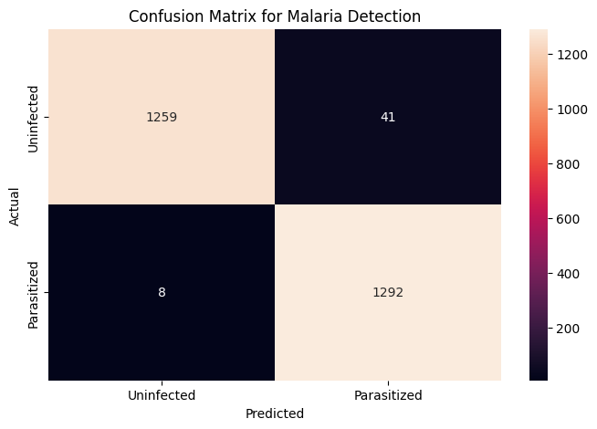

**Plotting the train and the validation curves**

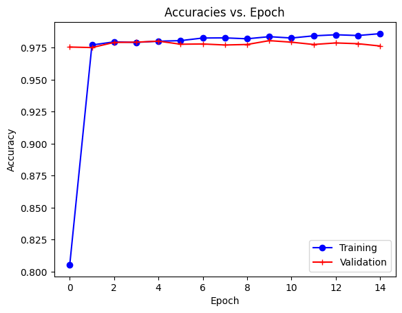

|  | cnn_model_base | cnn_model_1 |
| --- | --- | --- |
| description | 2x conv layers, 1 fc layer, relu, no regulariz... | 3x conv layers, 3 fc layers, relu, dropout reg... |
| # trainable parameters | 1053762 | 302178 |
| epochs ran | 18 | 15 |
| training accuracy | 0.9972 | 0.986 |
| validation accuracy | 0.9649 | 0.9764 |
| test accuracy | 0.9669 | 0.9812 |
| test precision (parasitized) | 0.9765 | 0.9692 |
| test recall (parasitized) | 0.9569 | 0.9938 |

### **Think about it:**

Now let's build a model with LeakyRelu as the activation function

- Can the model performance be improved if we change our activation function to LeakyRelu?
- Can BatchNormalization improve our model?

Let us try to build a model using BatchNormalization and using LeakyRelu as our activation function.

### **Model 2 with Batch Normalization**

### **Building the Model**

```
Model: "sequential"
_________________________________________________________________
 Layer (type)                Output Shape              Param #
=================================================================
 conv2d (Conv2D)             (None, 64, 64, 64)        1792

 leaky_re_lu (LeakyReLU)     (None, 64, 64, 64)        0

 max_pooling2d (MaxPooling2D  (None, 32, 32, 64)       0
 )

 conv2d_1 (Conv2D)           (None, 32, 32, 32)        18464

 leaky_re_lu_1 (LeakyReLU)   (None, 32, 32, 32)        0

 max_pooling2d_1 (MaxPooling  (None, 16, 16, 32)       0
 2D)

 conv2d_2 (Conv2D)           (None, 16, 16, 32)        9248

 leaky_re_lu_2 (LeakyReLU)   (None, 16, 16, 32)        0

 max_pooling2d_2 (MaxPooling  (None, 8, 8, 32)         0
 2D)

 flatten (Flatten)           (None, 2048)              0

 dense (Dense)               (None, 128)               262272

 leaky_re_lu_3 (LeakyReLU)   (None, 128)               0

 dropout (Dropout)           (None, 128)               0

 batch_normalization (BatchN  (None, 128)              512
 ormalization)

 dense_1 (Dense)             (None, 64)                8256

 leaky_re_lu_4 (LeakyReLU)   (None, 64)                0

 dropout_1 (Dropout)         (None, 64)                0

 batch_normalization_1 (Batc  (None, 64)               256
 hNormalization)

 dense_2 (Dense)             (None, 32)                2080

 leaky_re_lu_5 (LeakyReLU)   (None, 32)                0

 dropout_2 (Dropout)         (None, 32)                0

 batch_normalization_2 (Batc  (None, 32)               128
 hNormalization)

 dense_3 (Dense)             (None, 2)                 66

=================================================================
Total params: 303,074
Trainable params: 302,626
Non-trainable params: 448
_________________________________________________________________
```

### **Compiling the model**

**Using callbacks**

**Fit and train the model**

**Plotting the train and validation accuracy**

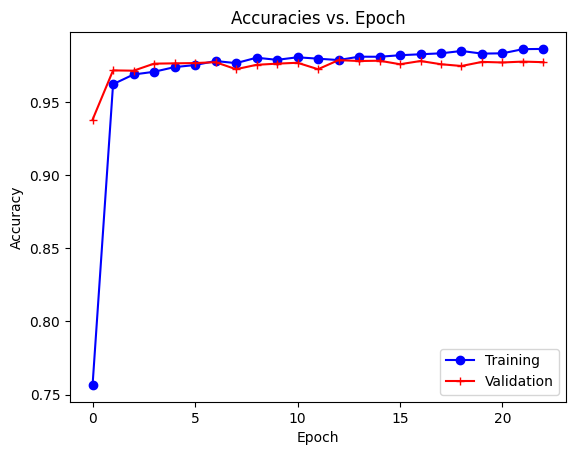

### **Evaluating the model**

```
Test accuracy of cnn_model_2:  0.98
```

#### **Observations and insights: *__***

- The validation accuracy shows a slight oscillating behavior probably due to the Batch Normalization causing some overshoot when trying to normalize the trained parameters in the layers of the fully connected network. As epochs increase the validation accuracy seems to settle down but it actually keeps on having some ripple.
- LeakyReLU does not help either to improve the overall accuracy of the model. For this relatively shallow network, the effect of sparsity achieved by ReLU in *cnn_model_1* seems to be more beneficial.
- There's no apparent benefit of using BatchNormalization as the model is stil overfitting slightly and there's no significant improvement in the computation time.

**Generate the classification report and confusion matrix**

```
Classification Report:

              precision    recall  f1-score   support

         0.0       0.99      0.97      0.98      1300
         1.0       0.97      0.99      0.98      1300

    accuracy                           0.98      2600
   macro avg       0.98      0.98      0.98      2600
weighted avg       0.98      0.98      0.98      2600
```

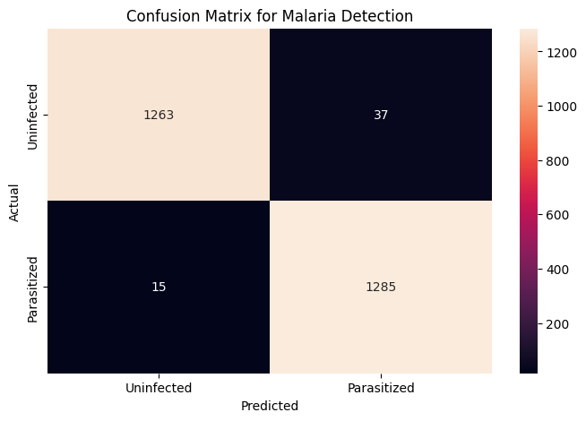

|  | cnn_model_base | cnn_model_1 | cnn_model_2 |
| --- | --- | --- | --- |
| description | 2x conv layers, 1 fc layer, relu, no regulariz... | 3x conv layers, 3 fc layers, relu, dropout reg... | 3x conv layers, 3 fc layers, Leaky relu, dropo... |
| # trainable parameters | 1053762 | 302178 | 302626 |
| epochs ran | 18 | 15 | 23 |
| training accuracy | 0.9972 | 0.986 | 0.9862 |
| validation accuracy | 0.9649 | 0.9764 | 0.9772 |
| test accuracy | 0.9669 | 0.9812 | 0.98 |
| test precision (parasitized) | 0.9765 | 0.9692 | 0.972 |
| test recall (parasitized) | 0.9569 | 0.9938 | 0.9885 |

### **Think About It :**

- Can we improve the model with Image Data Augmentation?
- References to image data augmentation can be seen below:
  - [Image Augmentation for Computer Vision](https://www.mygreatlearning.com/blog/understanding-data-augmentation/)
  - [How to Configure Image Data Augmentation in Keras?](https://machinelearningmastery.com/how-to-configure-image-data-augmentation-when-training-deep-learning-neural-networks/)

### **Model 3 with Data Augmentation**

### **Use image data generator**

```
((19966, 64, 64, 3), (19966, 2), (4992, 64, 64, 3), (4992, 2))
```

### **Think About It :**

- Check if the performance of the model can be improved by changing different parameters in the ImageDataGenerator.

#### **Visualizing Augmented images**

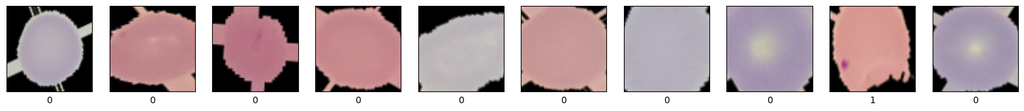

#### **Observations and insights: *__***

- Parasitized cells show a stain pattern in which color is more relevant than shape. Therefore, augmenting the data with flips or rotations may not be beneficial as the CNN won't give much weight to shape patterns anyways.
- Applying a zoom in transformation is not recommended as the stain pattern may remain out of scope and the CNN could get confused.
- Applying some sort of color contrast transformation could be helpful instead. However, when using the brightnees_range parameter the images turned out to be all black.

### **Building the Model**

Let's use the same architecture as *cnn_model_1* to fit the augmented data.

```
Model: "sequential"
_________________________________________________________________
 Layer (type)                Output Shape              Param #
=================================================================
 conv2d (Conv2D)             (None, 64, 64, 64)        1792

 max_pooling2d (MaxPooling2D  (None, 32, 32, 64)       0
 )

 conv2d_1 (Conv2D)           (None, 32, 32, 32)        18464

 max_pooling2d_1 (MaxPooling  (None, 16, 16, 32)       0
 2D)

 conv2d_2 (Conv2D)           (None, 16, 16, 32)        9248

 max_pooling2d_2 (MaxPooling  (None, 8, 8, 32)         0
 2D)

 flatten (Flatten)           (None, 2048)              0

 dense (Dense)               (None, 128)               262272

 dropout (Dropout)           (None, 128)               0

 dense_1 (Dense)             (None, 64)                8256

 dropout_1 (Dropout)         (None, 64)                0

 dense_2 (Dense)             (None, 32)                2080

 dropout_2 (Dropout)         (None, 32)                0

 dense_3 (Dense)             (None, 2)                 66

=================================================================
Total params: 302,178
Trainable params: 302,178
Non-trainable params: 0
_________________________________________________________________
```

### **Evaluating the model**

**Plot the train and validation accuracy**

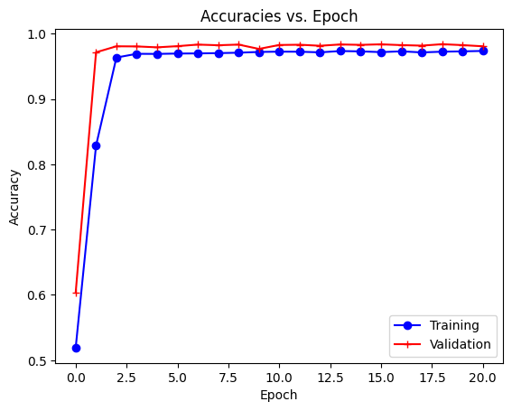

**Plotting the classification report and confusion matrix**

```
Classification Report:

              precision    recall  f1-score   support

         0.0       1.00      0.97      0.98      1300
         1.0       0.97      1.00      0.98      1300

    accuracy                           0.98      2600
   macro avg       0.98      0.98      0.98      2600
weighted avg       0.98      0.98      0.98      2600
```

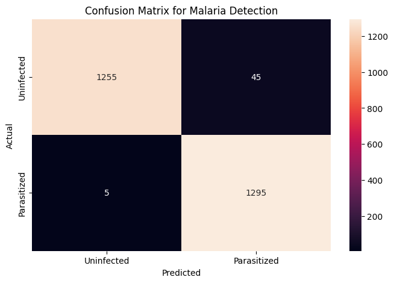

- The perfomance is very similar to *cnn_model_1*, meaning that the data augmentation transformations were good enough to keep the parasitized stain pattern detectable.
- However, the computation time is significantly longer, probably due to data augmentation running on the fly while fitting.

|  | cnn_model_base | cnn_model_1 | cnn_model_2 | cnn_model_3 |
| --- | --- | --- | --- | --- |
| description | 2x conv layers, 1 fc layer, relu, no regulariz... | 3x conv layers, 3 fc layers, relu, dropout reg... | 3x conv layers, 3 fc layers, Leaky relu, dropo... | cnn_model_1 with data augmentation |
| # trainable parameters | 1053762 | 302178 | 302626 | 302178 |
| epochs ran | 18 | 15 | 23 | 21 |
| training accuracy | 0.9972 | 0.986 | 0.9862 | 0.9737 |
| validation accuracy | 0.9649 | 0.9764 | 0.9772 | 0.9808 |
| test accuracy | 0.9669 | 0.9812 | 0.98 | 0.9808 |
| test precision (parasitized) | 0.9765 | 0.9692 | 0.972 | 0.9664 |
| test recall (parasitized) | 0.9569 | 0.9938 | 0.9885 | 0.9962 |

**Now, let us try to use a pretrained model like VGG16 and check how it performs on our data.**

### **Pre-trained model (VGG16)**

- Import VGG16 network upto any layer you choose
- Add Fully Connected Layers on top of it

```
Downloading data from https://storage.googleapis.com/tensorflow/keras-applications/vgg16/vgg16_weights_tf_dim_ordering_tf_kernels_notop.h5
```

```
Model: "vgg16"
_________________________________________________________________
 Layer (type)                Output Shape              Param #
=================================================================
 input_1 (InputLayer)        [(None, 64, 64, 3)]       0

 block1_conv1 (Conv2D)       (None, 64, 64, 64)        1792

 block1_conv2 (Conv2D)       (None, 64, 64, 64)        36928

 block1_pool (MaxPooling2D)  (None, 32, 32, 64)        0

 block2_conv1 (Conv2D)       (None, 32, 32, 128)       73856

 block2_conv2 (Conv2D)       (None, 32, 32, 128)       147584

 block2_pool (MaxPooling2D)  (None, 16, 16, 128)       0

 block3_conv1 (Conv2D)       (None, 16, 16, 256)       295168

 block3_conv2 (Conv2D)       (None, 16, 16, 256)       590080

 block3_conv3 (Conv2D)       (None, 16, 16, 256)       590080

 block3_pool (MaxPooling2D)  (None, 8, 8, 256)         0

 block4_conv1 (Conv2D)       (None, 8, 8, 512)         1180160

 block4_conv2 (Conv2D)       (None, 8, 8, 512)         2359808

 block4_conv3 (Conv2D)       (None, 8, 8, 512)         2359808

 block4_pool (MaxPooling2D)  (None, 4, 4, 512)         0

 block5_conv1 (Conv2D)       (None, 4, 4, 512)         2359808

 block5_conv2 (Conv2D)       (None, 4, 4, 512)         2359808

 block5_conv3 (Conv2D)       (None, 4, 4, 512)         2359808

 block5_pool (MaxPooling2D)  (None, 2, 2, 512)         0

 global_max_pooling2d (Globa  (None, 512)              0
 lMaxPooling2D)

=================================================================
Total params: 14,714,688
Trainable params: 14,714,688
Non-trainable params: 0
_________________________________________________________________
```

### **Compiling the model**

```
Model: "sequential"
_________________________________________________________________
 Layer (type)                Output Shape              Param #
=================================================================
 vgg16 (Functional)          (None, 512)               14714688

 flatten (Flatten)           (None, 512)               0

 dense (Dense)               (None, 128)               65664

 dropout (Dropout)           (None, 128)               0

 dense_1 (Dense)             (None, 64)                8256

 dropout_1 (Dropout)         (None, 64)                0

 dense_2 (Dense)             (None, 32)                2080

 dropout_2 (Dropout)         (None, 32)                0

 dense_3 (Dense)             (None, 2)                 66

=================================================================
Total params: 14,790,754
Trainable params: 76,066
Non-trainable params: 14,714,688
_________________________________________________________________
```

**using callbacks**

**Fit and Train the model**

**Plot the train and validation accuracy**

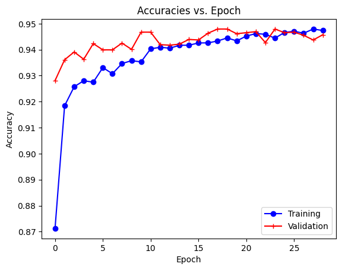

### **Observations and insights: **_****

- What can be observed from the validation and train curves?
  - The model is generalizing very well as the training and validation accuracies hand go by hand

### **Evaluating the model**

**Plotting the classification report and confusion matrix**

```
Classification Report:

              precision    recall  f1-score   support

         0.0       0.96      0.92      0.94      1300
         1.0       0.92      0.96      0.94      1300

    accuracy                           0.94      2600
   macro avg       0.94      0.94      0.94      2600
weighted avg       0.94      0.94      0.94      2600
```

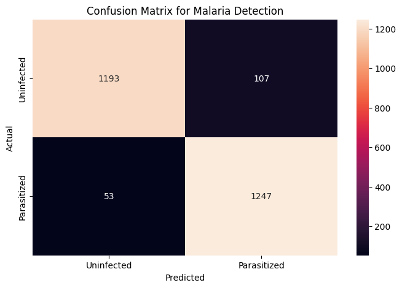

- Although the model generalizes well, its accuracy has decreased. This may be related to the fact that VGG16 doesn't use max pooling in between the convolutional layers of the last block.

|  | cnn_model_base | cnn_model_1 | cnn_model_2 | cnn_model_3 | cnn_model_4 |
| --- | --- | --- | --- | --- | --- |
| description | 2x conv layers, 1 fc layer, relu, no regulariz... | 3x conv layers, 3 fc layers, relu, dropout reg... | 3x conv layers, 3 fc layers, Leaky relu, dropo... | cnn_model_1 with data augmentation | pre-trained vgg16 + cnn_model_1 fc layers |
| # trainable parameters | 1053762 | 302178 | 302626 | 302178 | 76066 |
| epochs ran | 18 | 15 | 23 | 21 | 29 |
| training accuracy | 0.9972 | 0.986 | 0.9862 | 0.9737 | 0.9474 |
| validation accuracy | 0.9649 | 0.9764 | 0.9772 | 0.9808 | 0.9457 |
| test accuracy | 0.9669 | 0.9812 | 0.98 | 0.9808 | 0.9385 |
| test precision (parasitized) | 0.9765 | 0.9692 | 0.972 | 0.9664 | 0.921 |
| test recall (parasitized) | 0.9569 | 0.9938 | 0.9885 | 0.9962 | 0.9592 |

### **Think about it:**

- What observations and insights can be drawn from the confusion matrix and classification report?
- Choose the model with the best accuracy scores from all the above models and save it as a final model.

## **Final Model Selection**

|  | cnn_model_base | cnn_model_1 | cnn_model_2 | cnn_model_3 | cnn_model_4 |
| --- | --- | --- | --- | --- | --- |
| description | 2x conv layers, 1 fc layer, relu, no regulariz... | 3x conv layers, 3 fc layers, relu, dropout reg... | 3x conv layers, 3 fc layers, Leaky relu, dropo... | cnn_model_1 with data augmentation | pre-trained vgg16 + cnn_model_1 fc layers |
| # trainable parameters | 1053762 | 302178 | 302626 | 302178 | 76066 |
| epochs ran | 18 | 15 | 23 | 21 | 29 |
| training accuracy | 0.9972 | 0.986 | 0.9862 | 0.9737 | 0.9474 |
| validation accuracy | 0.9649 | 0.9764 | 0.9772 | 0.9808 | 0.9457 |
| test accuracy | 0.9669 | 0.9812 | 0.98 | 0.9808 | 0.9385 |
| test precision (parasitized) | 0.9765 | 0.9692 | 0.972 | 0.9664 | 0.921 |
| test recall (parasitized) | 0.9569 | 0.9938 | 0.9885 | 0.9962 | 0.9592 |

Some other models could be added to this table that could bring some improvements. Some examples are:

- Use HSV images to feed *cnn_model_1*: providing images with better color contrast can make the stain pattern common in the parasitized be easier to extract
- Use expanded data augmented dataset: increase the numer of samples in the original dataset to improve accuracy
- Use pre-trained models that are known to perform well when detecting color patterns

#### **The chosen model: *cnn_model_1***

Out of the 5 CNN models presented in this notebook, *cnn_mode_1* is the best model for the following reasons:

- Simplicity: It achieves an overall test accuracy of more than 98% with only 3 convolutional layers and 3 fully connected layers, making it quick to train.
- Efficient: With a few trainable parameters it is able to extract the most important features and combine them in such a way that it can accurately detect malaria patterns in the cells images.
- High recall: In this application, the recall to detect a parasitized cell is the most important score as it indicates how many actual parisizited cells the model is expected to classify as uninfected. This is critical because it is preferable to treat for malaria someone who is actually uninfected rather than leaving someone who does have malaria untreated. With a recall > 99%, *cnn_model_1* would misdiagnose less than 1 person every 100 of being uninfected when actually parasitized.
- High accuracy: when classifying unseen cell images this model can give us overall around 98% confidence that the resulting prediction is correct.

Model *cnn_model_1* performs well because it abstracts away the location of the parasitized stain pattern disregarding a specific shape and rather focusing on color. This feature extraction is possible thanks to the 3 convolutional layers and the max pooling done after each of them. Once the right features are available at the flatten layer, then the 3 fully connected layers with dropout learn the right combinations that minimize the loss function.

The model may be further improved by training it on a larger dataset, trying differents optimizers that can avoid local minima, and exploring on architectures that can enhance color pattern feauture extraction.

## **Final Submission**

#### **Complementary model**

As a complement to the previous milestone submission, let's dive into the hypothesis that training our *cnn_model_1* with HSV images could improve its performance.

```
(0, 255)
```

```
(0, 255)
```

```
Model: "sequential"
_________________________________________________________________
 Layer (type)                Output Shape              Param #
=================================================================
 conv2d (Conv2D)             (None, 64, 64, 64)        1792

 max_pooling2d (MaxPooling2D  (None, 32, 32, 64)       0
 )

 conv2d_1 (Conv2D)           (None, 32, 32, 32)        18464

 max_pooling2d_1 (MaxPooling  (None, 16, 16, 32)       0
 2D)

 conv2d_2 (Conv2D)           (None, 16, 16, 32)        9248

 max_pooling2d_2 (MaxPooling  (None, 8, 8, 32)         0
 2D)

 flatten (Flatten)           (None, 2048)              0

 dense (Dense)               (None, 128)               262272

 dropout (Dropout)           (None, 128)               0

 dense_1 (Dense)             (None, 64)                8256

 dropout_1 (Dropout)         (None, 64)                0

 dense_2 (Dense)             (None, 32)                2080

 dropout_2 (Dropout)         (None, 32)                0

 dense_3 (Dense)             (None, 2)                 66

=================================================================
Total params: 302,178
Trainable params: 302,178
Non-trainable params: 0
_________________________________________________________________
```

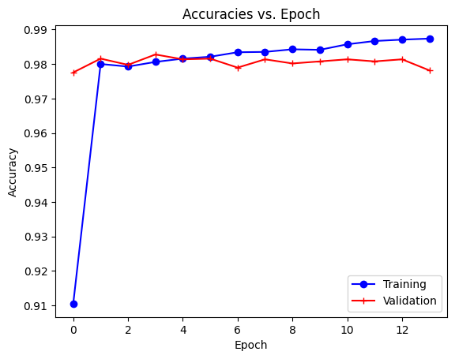

```
Classification Report:

              precision    recall  f1-score   support

         0.0       0.99      0.98      0.98      1300
         1.0       0.98      0.99      0.99      1300

    accuracy                           0.98      2600
   macro avg       0.99      0.98      0.98      2600
weighted avg       0.99      0.98      0.98      2600
```

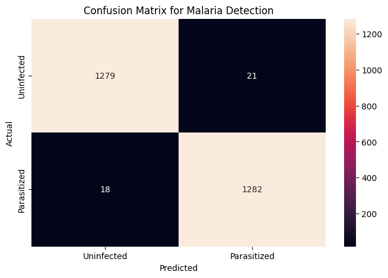

|  | cnn_model_base | cnn_model_1 | cnn_model_2 | cnn_model_3 | cnn_model_4 | cnn_model_hsv |
| --- | --- | --- | --- | --- | --- | --- |
| description | 2x conv layers, 1 fc layer, relu, no regulariz... | 3x conv layers, 3 fc layers, relu, dropout reg... | 3x conv layers, 3 fc layers, Leaky relu, dropo... | cnn_model_1 with data augmentation | pre-trained vgg16 + cnn_model_1 fc layers | cnn_model_1 with HSV images |
| # trainable parameters | 1053762 | 302178 | 302626 | 302178 | 76066 | 302178 |
| epochs ran | 18 | 15 | 23 | 21 | 29 | 14 |
| training accuracy | 0.9972 | 0.986 | 0.9862 | 0.9737 | 0.9474 | 0.9874 |
| validation accuracy | 0.9649 | 0.9764 | 0.9772 | 0.9808 | 0.9457 | 0.9782 |
| test accuracy | 0.9669 | 0.9812 | 0.98 | 0.9808 | 0.9385 | 0.985 |
| test precision (parasitized) | 0.9765 | 0.9692 | 0.972 | 0.9664 | 0.921 | 0.9839 |
| test recall (parasitized) | 0.9569 | 0.9938 | 0.9885 | 0.9962 | 0.9592 | 0.9862 |

Some observations:

- Training *cnn_model_1* with HSV images instead of RGB images, as is, does seem to bring a slight improvement to the overall model performance.
- Specially with regards to the test precision for the 'parasitized' class which increased from ~97% to more than 98%.
- However, the test recall for the 'parasitized' class decreased below 99%.
- The fact that the difference in training with RGB or HSV images is not very significant suggests that the CNN is capable of properly weighting color contrast patterns on its own for detecting the parasitized cells.
- In this case, trying different optimizer hyperparameters can help in making the learnt parameters more accurate.

To conclude:

- In comparison to *cnn_model_1*, the above means that *cnn_model_hsv* is better at indicating that a cell is parasitized when it actually is parasitized but worse when indicating that a cell is uninfected when it actually is parasitized. Since for this application, as explained before, recall is more critical than precision, keeping *cnn_model_1* is therefore preferable.

#### **Executive Summary**

A classifier model is proposed to support malaria diagnosis by predicting infection from microscopy images of parasitized red blood cells. The model consists of a 6-layer Convolutional Neural Network (CNN) that classifies a cell image sample as *parasitized* or *uninfected*. With the available dataset, the model was found to be able to differentiate parasitized from uninfected cells with an overall accuracy of around 98%, while yielding a >99% confidence that the cells classified as uninfected are not parasitized cells.  
Although the performance of the model is quite good, further validation is required to ensure results are trustworthy. Using the model entails some limitations and risks such as reduced performance on unseen images processed differently than the training dataset.  
If a digital microscopy-based diagnosis system is already in place, integration of the proposed model should be cost-effective and bring repeatability, accuracy, and scalability to the diagnosis workflow. Contrarily, if such system is not yet available its engineering costs should be weighted with the long-term economic and healthcare management benefits that it could bring.  
Feedback from stakeholders such as healthcare authorities, governments and regulating bodies is required to further develop the proposed solution.

#### **Problem and Solution Summary**

Early diagnosis of malaria is critical to fight against a disease that keeps on threatening life and jeopardizing socioeconomic development in tropical regions where most of the cases are concentrated. Diagnostic testing of malaria through light microscopy requires inspection by a professional microscopist who may need to handle large amounts of samples in a repetitive and error-prone procedure. A method or tool that can automate this procedure may lead to more convenient and accurate diagnosis. As a result, limited healthcare resources can be better channeled.  
The objective of this project was to build a CNN classifier model that can support microscopy-based malaria diagnosis by classifying unseen red blood cell images as coming from a parasitized or an uninfected blood sample.  
The solution approach consisted in performing data exploration on the available dataset and iteratively building different CNN models based on the derived insights.  
The dataset is formed by colored microscopy cell images of different sizes divided in ~25000 images for training the model and 2600 images for testing its performance. The images are almost equally distributed in samples of the *parasitized* and *uninfected* classes. The dataset images were all resized to be 64x64 pixels and normalized to the max pixel value.  
Analysis of the RGB and HSV blood cell images revealed that parasitized cells show a particular color stain located in random positions and of varying shapes while uninfected cells are uniformly colored across their area. This suggested that a CNN that could learn such stain pattern would be able to perform well when classifying infected cells.  
Several CNN architectures and training techniques were considered to explore model improvements in terms of performance and complexity. Metrics such as trainable parameters, training and validation accuracy, and test precision and recall, were assessed during the model iterations. Techniques such as normalization, data augmentation and tranfer learning were applied and evaluated too.  
The chosen CNN model *cnn_model_1* consists of 3 convolutional layers with ReLU activation and max pooling and 3 fully connected layers with ReLU and dropout regularization. The model was chosen because in comparison with the other models it is the one that best balances simplicity, efficiency, high recall, and high accuracy. With a simple architecture and few trainable parameters, the model is able to differentiate parasitized from uninfected cells with an overall accuracy of around 98%, while yielding a >99% confidence that the cells classified as uninfected are not parasitized cells.  
Although further improvements and validation are required, implementing the proposed solution could make microscopy-based diagnosis of malaria much quicker, accurate and cheaper. This translates into earlier and more widespread diagnosis, resulting in better management of disease.

#### **Recommendations for Implementation**

As part of a microscopy-based malaria diagnosis system, the proposed CNN model may provide a valuable tool for healthcare professionals to more conveniently and accurately perform large malaria diagnosis campaigns in the most vulnerable areas where malaria is widespread. Blood samples are collected from people who are suspected to be infected, these samples are processed through light microscopy, and then the resulting blood cell images are fed to our CNN model which predicts whether the sample is parasitized or uninfected. The outcome of the classification process is communicated to the healthcare professional who then determines the right treatment for the affected person. This workflow may be repeated several times, but the accuracy of the cell classication step won't change. The whole process can be therefore less prone to errors, cheaper and be deployed more widely.  
There are some risks and limitations in using our CNN model as a diagnostic tool:

- the results obtained are related to tests done on 2600 samples images so there's a chance that the model doesn't generalize well on unseen images that differ too much from the original dataset
- it implicitly classifies the cells as of one class or the other based on probability >50%. This may not be convenient as the margin for classification decision is small.
- the model performs better on recall than on precision for classifying parasitized cells. Whether this is actually preferable or not should be consulted with a malaria treatment expert.
- Cell images should be larger or equal than 64x64 pixels so that the preprocessing doesn't reduce the image quality and the classification result is not biased

Regarding the technical implementation and integration of the model itself, there are some important points to consider:

- once trained, the model can be saved as hdf5 file and integrated in a pipeline for making predictions on images offline or online
- the model can be part of the prediction algorithm of an integrated software that may run on a server accessible from a PC that also connects to the cell images database
- the required computing power should be determined to properly run the model
- there should also be some GUI or report generator that a healthcare professional can used to make a call on the diagnosis and the required treatment

Overall, considering a CNN solution to the malaria detection problem as presented here brings convenience in terms of repeatability, accuracy and potential scalability. These benefits need to be weighted with the engineering costs that integrating such solution may have and the long-term impact that it may represent in managing malaria in heavily affected areas.